# Project Python Foundations: FoodHub Data Analysis

**Marks: 60**

### Context

The number of restaurants in New York is increasing day by day. Lots of students and busy professionals rely on those restaurants due to their hectic lifestyles. Online food delivery service is a great option for them. It provides them with good food from their favorite restaurants. A food aggregator company FoodHub offers access to multiple restaurants through a single smartphone app.

The app allows the restaurants to receive a direct online order from a customer. The app assigns a delivery person from the company to pick up the order after it is confirmed by the restaurant. The delivery person then uses the map to reach the restaurant and waits for the food package. Once the food package is handed over to the delivery person, he/she confirms the pick-up in the app and travels to the customer's location to deliver the food. The delivery person confirms the drop-off in the app after delivering the food package to the customer. The customer can rate the order in the app. The food aggregator earns money by collecting a fixed margin of the delivery order from the restaurants.

### Objective

The food aggregator company has stored the data of the different orders made by the registered customers in their online portal. They want to analyze the data to get a fair idea about the demand of different restaurants which will help them in enhancing their customer experience. Suppose you are hired as a Data Scientist in this company and the Data Science team has shared some of the key questions that need to be answered. Perform the data analysis to find answers to these questions that will help the company to improve the business.

### Data Description

The data contains the different data related to a food order. The detailed data dictionary is given below.

### Data Dictionary

- order_id: Unique ID of the order
- customer_id: ID of the customer who ordered the food
- restaurant_name: Name of the restaurant
- cuisine_type: Cuisine ordered by the customer
- cost: Cost of the order
- day_of_the_week: Indicates whether the order is placed on a weekday or weekend (The weekday is from Monday to Friday and the weekend is Saturday and Sunday)
- rating: Rating given by the customer out of 5
- food_preparation_time: Time (in minutes) taken by the restaurant to prepare the food. This is calculated by taking the difference between the timestamps of the restaurant's order confirmation and the delivery person's pick-up confirmation.
- delivery_time: Time (in minutes) taken by the delivery person to deliver the food package. This is calculated by taking the difference between the timestamps of the delivery person's pick-up confirmation and drop-off information

### Let us start by importing the required libraries

```python
# import libraries for data manipulation
import numpy as np
import pandas as pd

# import libraries for data visualization
import matplotlib.pyplot as plt
import seaborn as sns
pd.set_option('display.float_format', lambda x: '%.3f' % x)
```

### Understanding the structure of the data

```python
# uncomment and run the following lines for Google Colab
from google.colab import drive
drive.mount('/content/drive')
```

```python
# read the data
df = pd.read_csv('/content/drive/MyDrive/Colab Notebooks/ML/Python Project/foodhub_order_copy.csv')
# returns the first 5 rows
df.head()
```

|  | order_id | customer_id | restaurant_name | cuisine_type | cost_of_the_order | day_of_the_week | rating | food_preparation_time | delivery_time |
| --- | --- | --- | --- | --- | --- | --- | --- | --- | --- |
| 0 | 1477147 | 337525 | Hangawi | Korean | 30.750 | Weekend | Not given | 25 | 20 |
| 1 | 1477685 | 358141 | Blue Ribbon Sushi Izakaya | Japanese | 12.080 | Weekend | Not given | 25 | 23 |
| 2 | 1477070 | 66393 | Cafe Habana | Mexican | 12.230 | Weekday | 5 | 23 | 28 |
| 3 | 1477334 | 106968 | Blue Ribbon Fried Chicken | American | 29.200 | Weekend | 3 | 25 | 15 |
| 4 | 1478249 | 76942 | Dirty Bird to Go | American | 11.590 | Weekday | 4 | 25 | 24 |

#### Observations:

The DataFrame has 9 columns as mentioned in the Data Dictionary. Data in each row corresponds to the order placed by a customer.

### **Question 1:** How many rows and columns are present in the data? [0.5 mark]

```python
# df.shape to get dataframe's dimension and print to record the row and colum counts
df.shape
print('The data has', df.shape[0],'rows and', df.shape[1],'columns.')
```

```
The data has 1898 rows and 9 columns.
```

#### Observations:

### **Question 2:** What are the datatypes of the different columns in the dataset? (The info() function can be used) [0.5 mark]

```python
# use .info() to print a summary of the DataFrame
df.info()
```

```
<class 'pandas.core.frame.DataFrame'>
RangeIndex: 1898 entries, 0 to 1897
Data columns (total 9 columns):
 #   Column                 Non-Null Count  Dtype
---  ------                 --------------  -----
 0   order_id               1898 non-null   int64
 1   customer_id            1898 non-null   int64
 2   restaurant_name        1898 non-null   object
 3   cuisine_type           1898 non-null   object
 4   cost_of_the_order      1898 non-null   float64
 5   day_of_the_week        1898 non-null   object
 6   rating                 1898 non-null   object
 7   food_preparation_time  1898 non-null   int64
 8   delivery_time          1898 non-null   int64
dtypes: float64(1), int64(4), object(4)
memory usage: 133.6+ KB
```

## **Observations**:

There are three (3) data types: float64, int64 and string (object).

### **Question 3:** Are there any missing values in the data? If yes, treat them using an appropriate method. [1 mark]

```python
# df.isnull().sum() to aggregrate the number of missing values
df.isnull().sum()
```

```
order_id                 0
customer_id              0
restaurant_name          0
cuisine_type             0
cost_of_the_order        0
day_of_the_week          0
rating                   0
food_preparation_time    0
delivery_time            0
dtype: int64
```

```python
#prints the number of missing values
print('The data has 0 missing values.')
```

```
The data has 0 missing values.
```

### **Question 4:** Check the statistical summary of the data. What is the minimum, average, and maximum time it takes for food to be prepared once an order is placed? [2 marks]

```python
# df.decribe().T - .decribe() pulls the statistical summarry while .T transposes the variables to make them readable
df.describe().T
```

|  | count | mean | std | min | 25% | 50% | 75% | max |
| --- | --- | --- | --- | --- | --- | --- | --- | --- |
| order_id | 1898.000 | 1477495.500 | 548.050 | 1476547.000 | 1477021.250 | 1477495.500 | 1477969.750 | 1478444.000 |
| customer_id | 1898.000 | 171168.478 | 113698.140 | 1311.000 | 77787.750 | 128600.000 | 270525.000 | 405334.000 |
| cost_of_the_order | 1898.000 | 16.499 | 7.484 | 4.470 | 12.080 | 14.140 | 22.297 | 35.410 |
| food_preparation_time | 1898.000 | 27.372 | 4.632 | 20.000 | 23.000 | 27.000 | 31.000 | 35.000 |
| delivery_time | 1898.000 | 24.162 | 4.973 | 15.000 | 20.000 | 25.000 | 28.000 | 33.000 |

## **Observations**:

1. min_food_prep_time is 20mins
2. the average_food_prep_time is 27.37mins
3. max_food_prep_time is 35min

### **Question 5:** How many orders are not rated? [1 mark]

```python
# obtaining record count for 'rating' column
df['rating'].value_counts()
```

```
Not given    736
5            588
4            386
3            188
Name: rating, dtype: int64
```

```python
# percentage of each record count in 'rating' column
df['rating'].value_counts(normalize=True)
```

```
Not given   0.388
5           0.310
4           0.203
3           0.099
Name: rating, dtype: float64
```

```python
print('About 736 (39%) orders are not rated.')
```

```
About 736 (39%) orders are not rated.
```

### Exploratory Data Analysis (EDA)

### **Question 6:** Explore all the variables and provide observations on their distributions. (Generally, histograms, boxplots, countplots, etc. are used for univariate exploration.) [9 marks]

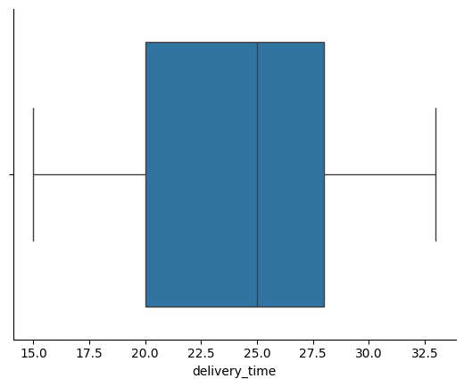

```python
# @title delivery time boxplot
sns.boxplot(data=df, x ='delivery_time')
plt.gca().spines[['top', 'right',]].set_visible(False)
```

## **Observations**

1. The median delivery time is about 25mins
2. Delivery time appears to be left skewed as the median is closer to Q3 than Q1
3. There are no visible outlier for delivery time

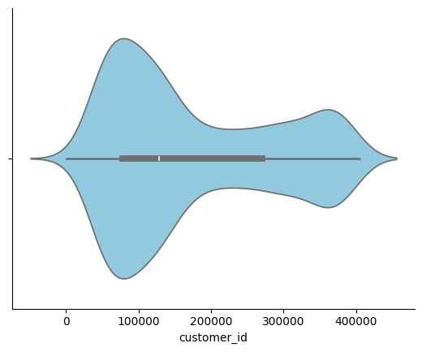

```python
# @title customer_id violin plot
sns.violinplot(data=df, x ='customer_id', color ='skyblue')
plt.gca().spines[['top', 'right',]].set_visible(False)
```

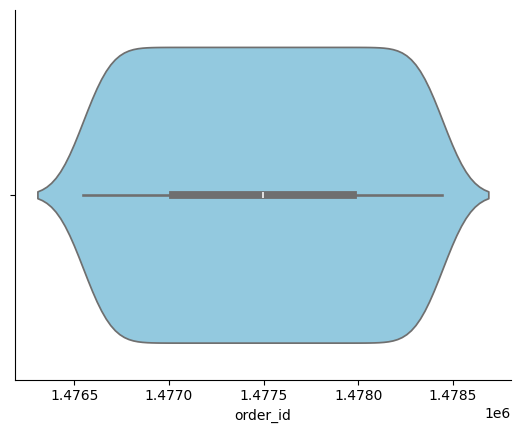

```python
# @title order_id violin plot
sns.violinplot(data=df, x ='order_id', color ='skyblue')
plt.gca().spines[['top', 'right',]].set_visible(False)
```

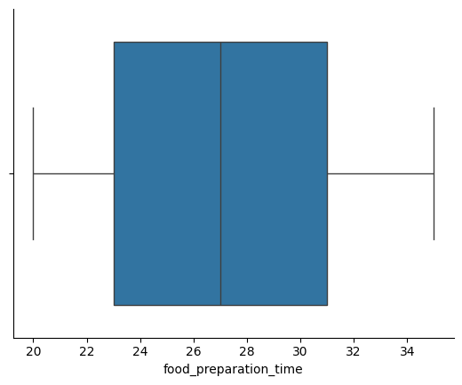

```python
# @title food_preparation_time distribution
sns.boxplot(data=df, x ='food_preparation_time')
plt.gca().spines[['top', 'right',]].set_visible(False)
```

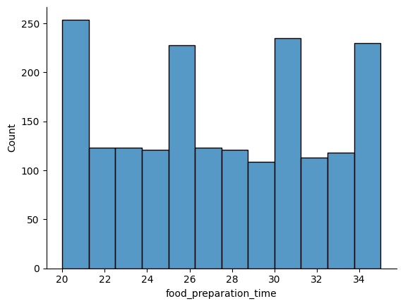

```python
# @title food preparation time histogram
sns.histplot(data=df, x ='food_preparation_time')
plt.gca().spines[['top', 'right',]].set_visible(False)
```

**Observation**

- Median food preparation time is around 27mins.
- A significant amout of oders are taking between 30-35min to be prepared. Are we able to improve this in order to reduce the total time?
- No skewness or outliers in food preparation time

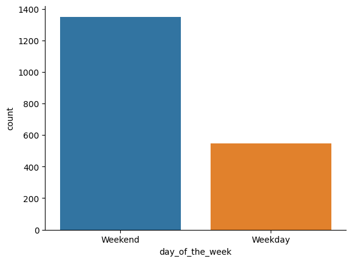

```python
# @title Day of the week count
sns.countplot(data=df, x='day_of_the_week', hue='day_of_the_week')
plt.gca().spines[['top', 'right',]].set_visible(False)
```

**Observations**

- There appears to be more orders on Weekend than on Weekdays.

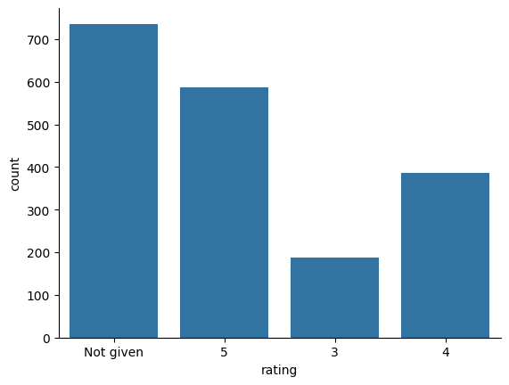

```python
# @title rating count
sns.countplot(data=df, x='rating')
plt.gca().spines[['top', 'right',]].set_visible(False)
```

**Observation**

1. About 39% of customers did not leave a rating. We may need to find a way to incetivize customers to give ratings.

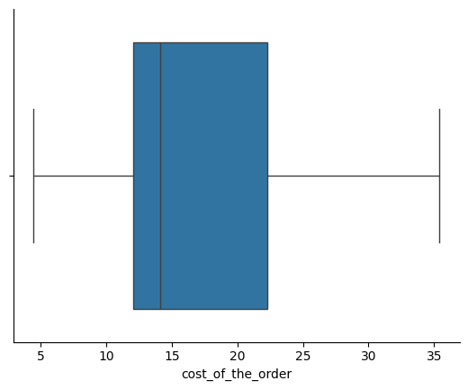

```python
# @title Cost of order distribution
sns.boxplot(data=df, x='cost_of_the_order')
plt.gca().spines[['top', 'right',]].set_visible(False)
```

**Observation**

- The median cost of order is about 14 dollars with the 75th percentile cost around 22 dollars and max order cost around $35.
- Cost of order is rightly skewed as seen in the longer whisker to the right.
- There are no visible presence of outliers.
- Further interaction of cost_of_the_order with other variables is suggested

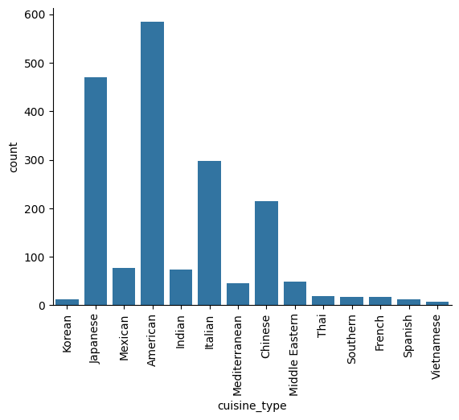

```python
# @title Cuisine count bar plot
sns.countplot(data=df, x='cuisine_type')
plt.xticks(rotation=90)
plt.gca().spines[['top', 'right',]].set_visible(False)
plt.show()
```

**Observation**

1. American cusines type appaers to be the most popular orders among customers. Closely followed by Japanese and Italian in a distant third.

### **Question 7**: Which are the top 5 restaurants in terms of the number of orders received? [1 mark]

```python
# using groupby to obtain top five restaurant
top_five_restaurant = df.groupby(['restaurant_name'])['order_id'].count().reset_index()
top_five_restaurant.sort_values(ascending=False, by='order_id')
```

|  | restaurant_name | order_id |
| --- | --- | --- |
| 136 | Shake Shack | 219 |
| 153 | The Meatball Shop | 132 |
| 21 | Blue Ribbon Sushi | 119 |
| 20 | Blue Ribbon Fried Chicken | 96 |
| 109 | Parm | 68 |
| ... | ... | ... |
| 85 | Klong | 1 |
| 83 | Kambi Ramen House | 1 |
| 77 | Il Bambino | 1 |
| 76 | Hunan Manor | 1 |
| 89 | Lamarca Pasta | 1 |

178 rows × 2 columns

#### **Observations**:

The top 5 restaurants are:

1. Shake Shack
2. The Meatball Shop
3. Blue Ribbon Sushi
4. Blue Ribbon Fried Chicken
5. Parm in that order.

### **Question 8**: Which is the most popular cuisine on weekends? [1 mark]

```python
# filtering weekend data to obtain restaurant
weekend_data = df[df['day_of_the_week'].isin(['Weekend'])]

# obtaining record count for cuisine type in weekend data
cuisine_counts = weekend_data['cuisine_type'].value_counts()

# pulling data with index of maximum values into popular cuisine
most_popular_cuisine = cuisine_counts.idxmax()

#prinitng result of most popular cuisine
print(f"The most popular cuisine on weekends is: {most_popular_cuisine}.")
```

```
The most popular cuisine on weekends is: American.
```

```python
print(cuisine_counts)
```

```
American          415
Japanese          335
Italian           207
Chinese           163
Mexican            53
Indian             49
Mediterranean      32
Middle Eastern     32
Thai               15
French             13
Korean             11
Southern           11
Spanish            11
Vietnamese          4
Name: cuisine_type, dtype: int64
```

#### **Observations**:

The most popular cuisine on weekends is **American**.

```python
# check for popular weekday cuisine type
weekday_data = df[df['day_of_the_week'].isin(['Weekday'])]
cuisine_counts_1 = weekday_data['cuisine_type'].value_counts()
most_popular_cuisine_1 = cuisine_counts_1.idxmax()
print(f"The most popular cuisine on weekdays is: {most_popular_cuisine_1}.")
```

```
The most popular cuisine on weekdays is: American.
```

```python
print(cuisine_counts_1)
```

```
American          169
Japanese          135
Italian            91
Chinese            52
Mexican            24
Indian             24
Middle Eastern     17
Mediterranean      14
Southern            6
French              5
Thai                4
Vietnamese          3
Korean              2
Spanish             1
Name: cuisine_type, dtype: int64
```

### **Question 9**: What percentage of the orders cost more than 20 dollars? [2 marks]

```python
# filtering for expensive order using the cost of order column
expensive_orders = df[df['cost_of_the_order']>20]
# calculating percentage of expensive orders
percentage_of_expensive_orders =(len(expensive_orders)/len(df)) * 100
# printing result
print(f"The percentage of orders costing more than $20 is: {percentage_of_expensive_orders:.2f}%.")
```

```
The percentage of orders costing more than $20 is: 29.24%.
```

## **Observations**:

1. 29.24% of the orders cost more than $20.

### **Question 10**: What is the mean order delivery time? [1 mark]

```python
# calculating mean average delivery time
avg_order_deliverytime = df['delivery_time'].mean()
print(f"The average delivery time is: {avg_order_deliverytime:.2f}min.")
```

```
The average delivery time is: 24.16min.
```

**Observations**:

1. The average delivery is 24.16mins.
2. There may be an opportunity to optimize for faster delivery time which may prompt customers to give postive feedback/rating.

### **Question 11:** The company has decided to give 20% discount vouchers to the top 3 most frequent customers. Find the IDs of these customers and the number of orders they placed. [1 mark]

```python
# counting customer id's to obtain highest ranking ids
customer_frequencies = df['customer_id'].value_counts()
# pulling top 3 customers
top_customers = customer_frequencies.head(3).index
print("\nTop 3 Customers and Order Counts: ")
#for statement to sort top 3 customers in descending order
for customer_id in top_customers:
   order_count = customer_frequencies[customer_id]
   print(f"Customer ID: {customer_id}, Number of Orders: {order_count}")
```

```
Top 3 Customers and Order Counts:
Customer ID: 52832, Number of Orders: 13
Customer ID: 47440, Number of Orders: 10
Customer ID: 83287, Number of Orders: 9
```

## **Observations**:

Top 3 Customers and Order Counts:

1. Customer ID: 52832, Number of Orders: 13
2. Customer ID: 47440, Number of Orders: 10
3. Customer ID: 83287, Number of Orders: 9

### **Question 12**: Perform a multivariate analysis to explore relationships between the important variables in the dataset. (It is a good idea to explore relations between numerical variables as well as relations between numerical and categorical variables) [10 marks]

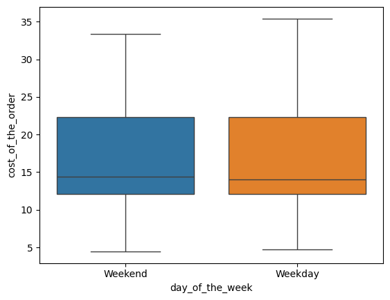

```python
# @title Cost of order vs day of week
sns.boxplot(data=df,x='day_of_the_week',y='cost_of_the_order', hue='day_of_the_week')
plt.show()
```

## **Observations**

- Comparing both boxplot for Weekend and Weekday, both plots appears to be skewed to the right as the median is closer to the the lower quartile Q1. However, Weekday plot appears to be more rightly skewed indicating that more cost of the order is in the upper part of the distribution on Weekdays. This may be consistent with workers buying more expensive orders on Weekdays compare to Weekends
- The upper quartile (Q3) or 75th percentile is consistent for both plots and there are no visible outliers for both.

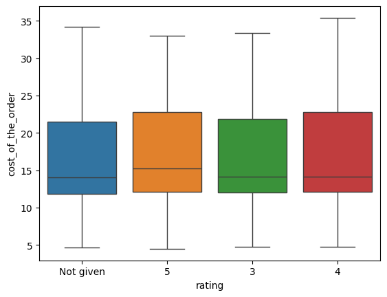

```python
# @title cost of order vs rating
sns.boxplot(data=df,x='rating',y='cost_of_the_order',hue='rating')
plt.show()
```

## **Observations**

- The orders with the highest ratings (5) appears to have a higher median cost of the order
- Those who did not give a rating and other lower ratings (i.e. 3 and 4) have a similar median cost of order.
- Each plot appears to be skewed to the right, indicating, regardless of rating, right side of the distribution of cost of order has more variability.

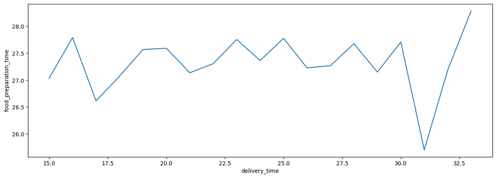

```python
import warnings
warnings.simplefilter(action='ignore', category=FutureWarning)
#import pandas
# @title Food preparation time by delivery time
plt.figure(figsize=(15,5))
sns.lineplot(data=df,x='delivery_time',y='food_preparation_time', ci=None)
plt.show()
```

## **Observations**

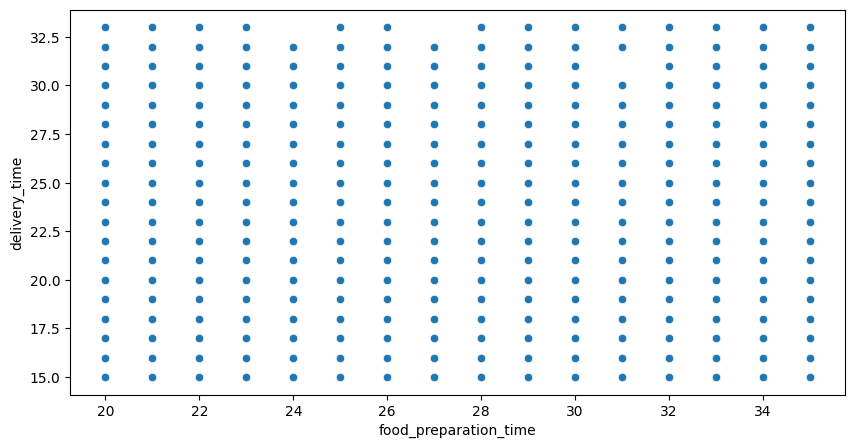

```python
# @title delivery time vs food preparation time
plt.figure(figsize=(10,5))
sns.scatterplot(data=df,x='food_preparation_time',y='delivery_time')
plt.show()
```

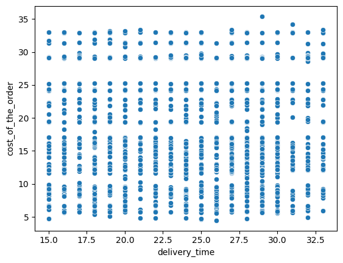

```python
# @title cost_of_the_order vs delivery time
sns.scatterplot(data=df, x='delivery_time',y='cost_of_the_order')
```

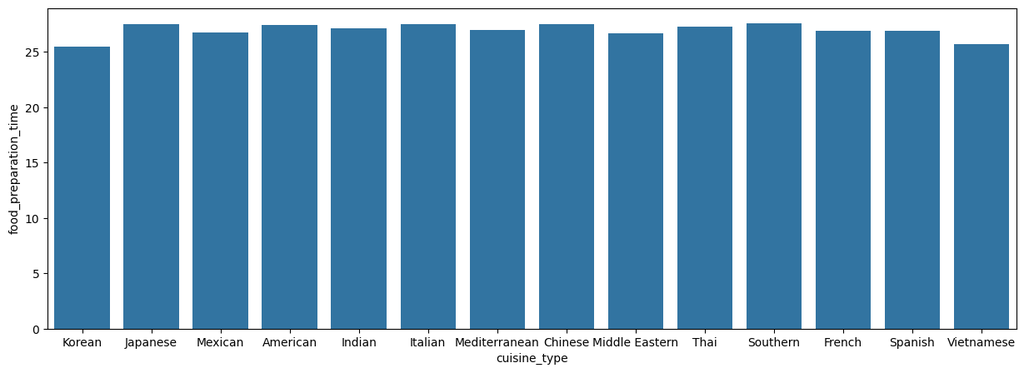

```python
# @title Food preparation time by cuisine type
plt.figure(figsize=(15,5))
sns.barplot(data=df,x='cuisine_type',y='food_preparation_time', ci=None)
plt.show()
```

## **Observation**

On average, it takes more than 25min to prepare each cuisine.

```python
df['rating'] = pd.to_numeric(df['rating'], errors='coerce')
```

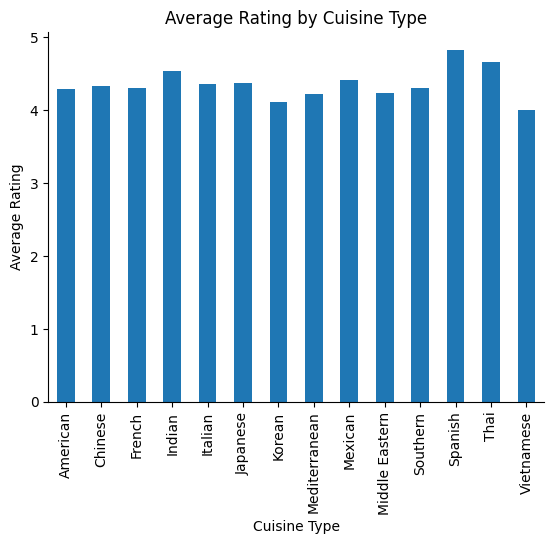

```python
# @title Average rating by cuisine type
df.groupby('cuisine_type')['rating'].mean().plot(kind='bar')
plt.title('Average Rating by Cuisine Type')
plt.xlabel('Cuisine Type')
plt.ylabel('Average Rating')
plt.gca().spines[['top', 'right',]].set_visible(False)
```

**Observations**

- Spanish cuisine type appears to have the highest average rating
- Most cuisine types have an average rating higher than 4, except for Vietnamese whose average rating is about 4

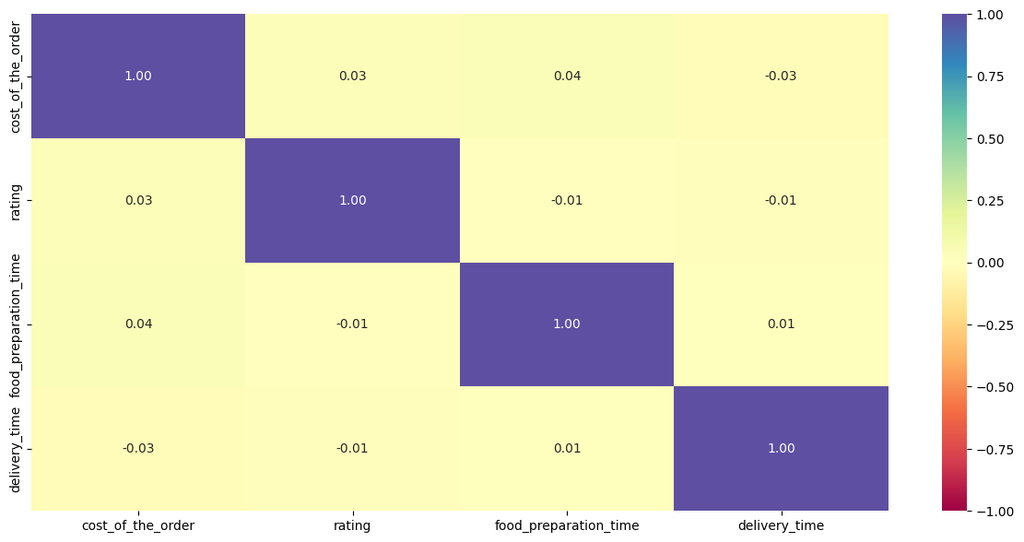

```python
orig_var = ['cost_of_the_order','rating','food_preparation_time','delivery_time']

corr = df[orig_var].corr()

# plot the heatmap
# @title Heatmap of correlation coefficients
plt.figure(figsize=(15, 7))
sns.heatmap(corr, annot=True, vmin=-1, vmax=1, fmt=".2f", cmap="Spectral")
plt.show()
```

## **Observations**

1. Delivery time column shows no correlation with cost_of_the_order column. This indicates there is little to no linear relationship between the two variables as orders are treated on a first come basis.
2. Cost_of_the_order has no correlation with food_preparation_time. This is consistent with our assumption that orders are processed as they come in and no preference based on cost of orders.
3. Food_preparation_time and delivery_time appear to also have no correlation.

### **Question 13:** The company wants to provide a promotional offer in the advertisement of the restaurants. The condition to get the offer is that the restaurants must have a rating count of more than 50 and the average rating should be greater than 4. Find the restaurants fulfilling the criteria to get the promotional offer. [3 marks]

```python
#filtering out 'Not given' rating to calculate mean of rating and rating count
#created a copy of the dataframe
df['filtered_rating'] = df['rating'][df['rating'] != 'Not given']
copy_df =df.copy()
```

```python
copy_df.head()
```

[output not shown]

```python
copy_df['filtered_rating'] = copy_df['filtered_rating'].astype(float)
copy_df['filtered_rating'].dtypes
copy_df.info()
```

[output not shown]

```python
# obtaining rating count and average ratings of the restaurant
restaurant_stats = copy_df.groupby('restaurant_name')['filtered_rating'].agg(['count', 'mean'])

# applying and checking for restaurants that meets the specified criteria
selected_restaurants = restaurant_stats[(restaurant_stats['count'] > 50) & (restaurant_stats['mean'] > 4)]

#printing out result sets of the selected restaurants that meet the criteria
print("Restaurants with rating count greater than 50 and average rating greater than 4:")
print(selected_restaurants.sort_values(ascending=False, by='count'))
```

```
Restaurants with rating count greater than 50 and average rating greater than 4:
                           count  mean
restaurant_name
Shake Shack                  133 4.278
The Meatball Shop             84 4.512
Blue Ribbon Sushi             73 4.219
Blue Ribbon Fried Chicken     64 4.328
```

### **Question 14:** The company charges the restaurant 25% on the orders having cost greater than 20 dollars and 15% on the orders having cost greater than 5 dollars. Find the net revenue generated by the company across all orders. [3 marks]

```python
# user defined function statement to create surcharge conditions
high_cost_delivery_surcharge = 0.25
low_cost_delivery_surcharge = 0.15
def compute_delivery_rev(cost_of_the_order):
  if cost_of_the_order > 20:
    return cost_of_the_order * high_cost_delivery_surcharge
  elif cost_of_the_order > 5:
    return cost_of_the_order * low_cost_delivery_surcharge
  else:
    return 0
```

```python
# creating a variable to store the surcharge value and applying the user defined function to calculate surcharge amount
df['surcharge_revenue'] = df['cost_of_the_order'].apply(compute_delivery_rev)

# sum up total surcharge as revenue generated
net_revenue = df['surcharge_revenue'].sum()

# printing result of sum of total revenue
print(f"\nThe net revenue generated accross all orders by the company is: ${net_revenue:.2f}")
```

```
The net revenue generated accross all orders by the company is: $6166.30
```

### **Question 15:** The company wants to analyze the total time required to deliver the food. What percentage of orders take more than 60 minutes to get delivered from the time the order is placed? (The food has to be prepared and then delivered.) [2 marks]

```python
#calculaing total time as sum of each time components
df['total_time'] = df['food_preparation_time'] + df['delivery_time']

# appplying the required condition to total time
long_total_delivery_time = df[df['total_time'] > 60]

# calculating percentage of orders greater than 60 minutes
percentage_long_total_delivery_time = (len(long_total_delivery_time) / len(df['total_time'])) * 100

#printing result
print(f"The percentage of orders whose total time takes more than 60 minutes is: {percentage_long_total_delivery_time:.2f}%")
```

```
The percentage of orders whose total time takes more than 60 minutes is: 10.54%
```

#### Observations:

### **Question 16:** The company wants to analyze the delivery time of the orders on weekdays and weekends. How does the mean delivery time vary during weekdays and weekends? [2 marks]

```python
# storing weekday and weekend data in new sets of variables
weekday_group = df['day_of_the_week'].isin(['Weekday'])
weekend_group = df['day_of_the_week'].isin(['Weekend'])

#obtaining mean delivery time for each day of the week
mean_delivery_time_weekday = df.loc[weekday_group, 'delivery_time'].mean()
mean_delivery_time_weekend = df.loc[weekend_group, 'delivery_time'].mean()

#printing out result sets for each day of the week
print(f"The mean delivery time on Weekdays: {mean_delivery_time_weekday:.2f} minutes.")
print(f"The mean delivery time on Weekends: {mean_delivery_time_weekend:.2f} minutes.")
```

```
The mean delivery time on Weekdays: 28.34 minutes.
The mean delivery time on Weekends: 22.47 minutes.
```

### Conclusion and Recommendations

### **Question 17:** What are your conclusions from the analysis? What recommendations would you like to share to help improve the business? (You can use cuisine type and feedback ratings to drive your business recommendations.) [6 marks]

### Conclusions:

- Top 5 demand generating restaurants based on order receieved are Shake Shack, The Meatball Shop, Blue Ribbon Sushi, Blue Ribbon Fried Chicken, Parm in that order.
- American cuisine appears to be the most popular on both days of the week.
- Restaurant received more orders during weekends compared to weekdays
- Food preparation time stays the same for each type of cuisine. Albeit a significant amount of oders are taking between 30-35min to be prepared
- There is no observable correlations among the numerical variables
- About 39% of customers did not leave a rating. This may be due to issues with thier orders or they just decided not leave a rating.
- Spanish cusisine type appears to have the highest average rating.
- It takes more than 26% more time to deliver on weekdays compared to weekends.

### Recommendations:

- Incentivize restaurants to improve on food preparation time to reduce total time taken to deliver orders.
- Plan adequately with restaurants and delivery drivers for weekend surge orders to reduce customer wait time
- Optimize for faster delivery time during Weekdays. This may drop the total time taken to deliver orders and improve customer experience.
- Encourage customers to leave ratings as more ratings will provide additional data points to explore.
- Further analysis is required to understand why almost 40% of the customers did not leave a rating.